# Risk Factor Analysis

## Outcome Variable

**Outcome Variable:** whz

## Predictor Variables

**Intervention Variable:** fhtcm

**Adjustment Set:**

- arm
- W_mage
- W_fage
- meducyrs
- feducyrs
- W_mhtcm
- W_mwtkg
- W_mbmi
- single
- delta_W_mage
- delta_W_fage
- delta_meducyrs
- delta_feducyrs
- delta_W_mhtcm
- delta_W_mwtkg
- delta_W_mbmi
- delta_single

## Stratifying Variables

The analysis was stratified on these variable(s):

- agecat
- studyid
- country

## Data Summary

| agecat | studyid | country | fhtcm | n_cell | n | outcome_variable |
| --- | --- | --- | --- | --- | --- | --- |
| Birth | COHORTS | GUATEMALA | >=167 cm | 26 | 192 | whz |
| Birth | COHORTS | GUATEMALA | <162 cm | 112 | 192 | whz |
| Birth | COHORTS | GUATEMALA | [162-167) cm | 54 | 192 | whz |
| Birth | Keneba | GAMBIA | >=167 cm | 733 | 1114 | whz |
| Birth | Keneba | GAMBIA | <162 cm | 83 | 1114 | whz |
| Birth | Keneba | GAMBIA | [162-167) cm | 298 | 1114 | whz |
| Birth | PROBIT | BELARUS | >=167 cm | 11672 | 12461 | whz |
| Birth | PROBIT | BELARUS | <162 cm | 168 | 12461 | whz |
| Birth | PROBIT | BELARUS | [162-167) cm | 621 | 12461 | whz |
| Birth | SAS-CompFeed | INDIA | >=167 cm | 312 | 657 | whz |
| Birth | SAS-CompFeed | INDIA | <162 cm | 159 | 657 | whz |
| Birth | SAS-CompFeed | INDIA | [162-167) cm | 186 | 657 | whz |
| 6 months | COHORTS | GUATEMALA | >=167 cm | 44 | 336 | whz |
| 6 months | COHORTS | GUATEMALA | <162 cm | 198 | 336 | whz |
| 6 months | COHORTS | GUATEMALA | [162-167) cm | 94 | 336 | whz |
| 6 months | Keneba | GAMBIA | >=167 cm | 979 | 1510 | whz |
| 6 months | Keneba | GAMBIA | <162 cm | 113 | 1510 | whz |
| 6 months | Keneba | GAMBIA | [162-167) cm | 418 | 1510 | whz |
| 6 months | PROBIT | BELARUS | >=167 cm | 11142 | 11891 | whz |
| 6 months | PROBIT | BELARUS | <162 cm | 156 | 11891 | whz |
| 6 months | PROBIT | BELARUS | [162-167) cm | 593 | 11891 | whz |
| 6 months | SAS-CompFeed | INDIA | >=167 cm | 370 | 807 | whz |
| 6 months | SAS-CompFeed | INDIA | <162 cm | 193 | 807 | whz |
| 6 months | SAS-CompFeed | INDIA | [162-167) cm | 244 | 807 | whz |
| 6 months | SAS-FoodSuppl | INDIA | >=167 cm | 102 | 371 | whz |
| 6 months | SAS-FoodSuppl | INDIA | <162 cm | 148 | 371 | whz |
| 6 months | SAS-FoodSuppl | INDIA | [162-167) cm | 121 | 371 | whz |
| 24 months | COHORTS | GUATEMALA | >=167 cm | 72 | 532 | whz |
| 24 months | COHORTS | GUATEMALA | <162 cm | 311 | 532 | whz |
| 24 months | COHORTS | GUATEMALA | [162-167) cm | 149 | 532 | whz |
| 24 months | Keneba | GAMBIA | >=167 cm | 823 | 1298 | whz |
| 24 months | Keneba | GAMBIA | <162 cm | 96 | 1298 | whz |
| 24 months | Keneba | GAMBIA | [162-167) cm | 379 | 1298 | whz |
| 24 months | PROBIT | BELARUS | >=167 cm | 3386 | 3608 | whz |
| 24 months | PROBIT | BELARUS | <162 cm | 52 | 3608 | whz |
| 24 months | PROBIT | BELARUS | [162-167) cm | 170 | 3608 | whz |

The following strata were considered:

- agecat: 24 months, studyid: COHORTS, country: GUATEMALA
- agecat: 24 months, studyid: Keneba, country: GAMBIA
- agecat: 24 months, studyid: PROBIT, country: BELARUS
- agecat: 6 months, studyid: COHORTS, country: GUATEMALA
- agecat: 6 months, studyid: Keneba, country: GAMBIA
- agecat: 6 months, studyid: PROBIT, country: BELARUS
- agecat: 6 months, studyid: SAS-CompFeed, country: INDIA
- agecat: 6 months, studyid: SAS-FoodSuppl, country: INDIA
- agecat: Birth, studyid: COHORTS, country: GUATEMALA
- agecat: Birth, studyid: Keneba, country: GAMBIA
- agecat: Birth, studyid: PROBIT, country: BELARUS
- agecat: Birth, studyid: SAS-CompFeed, country: INDIA

## Methods Detail

We’re interested in the causal parameters $E[Y_a]$ for all values of $a \in \mathcal{A}$. These parameters represent the mean outcome if, possibly contrary to fact, we intervened to set all units to have $A=a$. Under the randomization and positivity assumptions, these are identified by the statistical parameters $\psi_a=E_W[E_{Y|A,W}(Y|A=a,W)]$. In addition, we’re interested in the mean of $Y$, $E[Y]$ under no intervention (the observed mean). We will estimate these parameters by using SuperLearner to fit the relevant likelihood factors – $E_{Y|A,W}(Y|A=a,W)$ and $p(A=a|W)$, and then updating our likelihood fit using a joint TMLE.

For unadjusted analyses ($W=\{\}$), initial likelihoods were estimated using Lrnr_glm to estimate the simple $E(Y|A)$ and Lrnr_mean to estimate $p(A)$. For adjusted analyses, a small library containing Lrnr_glmnet, Lrnr_xgboost, and Lrnr_mean was used.

Having estimated these parameters, we will then use the delta method to estimate relative risks and attributable risks relative to a prespecified baseline level of $A$.

# Results Detail

## Results Plots

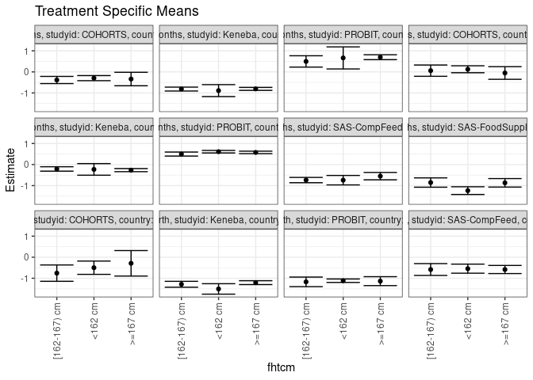

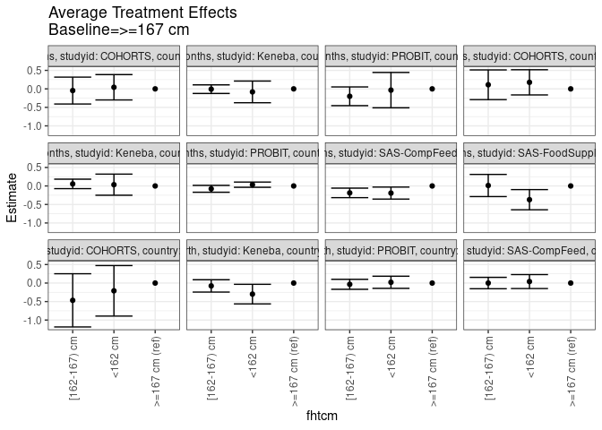

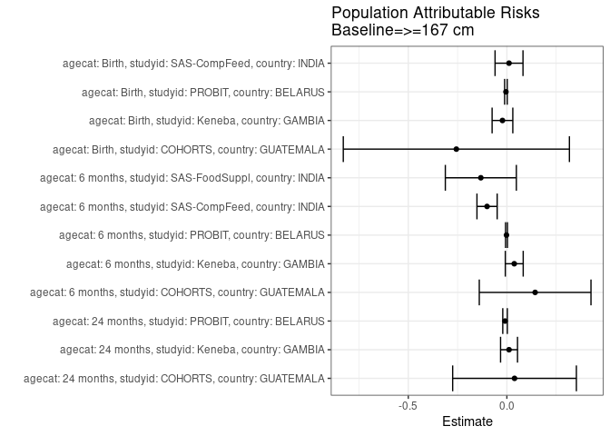

## Results Table

### Parameter: TSM

| agecat | studyid | country | intervention_level | baseline_level | estimate | ci_lower | ci_upper |
| --- | --- | --- | --- | --- | --- | --- | --- |
| Birth | COHORTS | GUATEMALA | >=167 cm | NA | -0.2888421 | -0.8941058 | 0.3164216 |
| Birth | COHORTS | GUATEMALA | <162 cm | NA | -0.4984468 | -0.8148195 | -0.1820742 |
| Birth | COHORTS | GUATEMALA | [162-167) cm | NA | -0.7561497 | -1.1438323 | -0.3684670 |
| Birth | Keneba | GAMBIA | >=167 cm | NA | -1.2080282 | -1.2992647 | -1.1167918 |
| Birth | Keneba | GAMBIA | <162 cm | NA | -1.5064380 | -1.7540924 | -1.2587836 |
| Birth | Keneba | GAMBIA | [162-167) cm | NA | -1.2850242 | -1.4245209 | -1.1455275 |
| Birth | PROBIT | BELARUS | >=167 cm | NA | -1.1371059 | -1.3486810 | -0.9255308 |
| Birth | PROBIT | BELARUS | <162 cm | NA | -1.1160999 | -1.1984667 | -1.0337331 |
| Birth | PROBIT | BELARUS | [162-167) cm | NA | -1.1711026 | -1.3988067 | -0.9433986 |
| Birth | SAS-CompFeed | INDIA | >=167 cm | NA | -0.5842626 | -0.7776482 | -0.3908771 |
| Birth | SAS-CompFeed | INDIA | <162 cm | NA | -0.5437044 | -0.7588653 | -0.3285435 |
| Birth | SAS-CompFeed | INDIA | [162-167) cm | NA | -0.5839248 | -0.8650768 | -0.3027728 |
| 6 months | COHORTS | GUATEMALA | >=167 cm | NA | -0.0523951 | -0.3525173 | 0.2477271 |
| 6 months | COHORTS | GUATEMALA | <162 cm | NA | 0.1242188 | -0.0402404 | 0.2886780 |
| 6 months | COHORTS | GUATEMALA | [162-167) cm | NA | 0.0585615 | -0.2086671 | 0.3257902 |
| 6 months | Keneba | GAMBIA | >=167 cm | NA | -0.2646441 | -0.3379743 | -0.1913140 |
| 6 months | Keneba | GAMBIA | <162 cm | NA | -0.2303006 | -0.5054821 | 0.0448809 |
| 6 months | Keneba | GAMBIA | [162-167) cm | NA | -0.2091437 | -0.3140603 | -0.1042271 |
| 6 months | PROBIT | BELARUS | >=167 cm | NA | 0.5757049 | 0.5164657 | 0.6349441 |
| 6 months | PROBIT | BELARUS | <162 cm | NA | 0.6103930 | 0.5510766 | 0.6697094 |
| 6 months | PROBIT | BELARUS | [162-167) cm | NA | 0.4984960 | 0.4034210 | 0.5935710 |
| 6 months | SAS-CompFeed | INDIA | >=167 cm | NA | -0.5497962 | -0.7250747 | -0.3745177 |
| 6 months | SAS-CompFeed | INDIA | <162 cm | NA | -0.7424898 | -0.9666214 | -0.5183583 |
| 6 months | SAS-CompFeed | INDIA | [162-167) cm | NA | -0.7369793 | -0.8630013 | -0.6109573 |
| 6 months | SAS-FoodSuppl | INDIA | >=167 cm | NA | -0.8677586 | -1.0695596 | -0.6659577 |
| 6 months | SAS-FoodSuppl | INDIA | <162 cm | NA | -1.2385545 | -1.4222289 | -1.0548801 |
| 6 months | SAS-FoodSuppl | INDIA | [162-167) cm | NA | -0.8551777 | -1.0762835 | -0.6340719 |
| 24 months | COHORTS | GUATEMALA | >=167 cm | NA | -0.3390720 | -0.6596213 | -0.0185227 |
| 24 months | COHORTS | GUATEMALA | <162 cm | NA | -0.2961196 | -0.4169815 | -0.1752577 |
| 24 months | COHORTS | GUATEMALA | [162-167) cm | NA | -0.3848581 | -0.5553081 | -0.2144080 |
| 24 months | Keneba | GAMBIA | >=167 cm | NA | -0.8073737 | -0.8774668 | -0.7372807 |
| 24 months | Keneba | GAMBIA | <162 cm | NA | -0.8893268 | -1.1735146 | -0.6051390 |
| 24 months | Keneba | GAMBIA | [162-167) cm | NA | -0.8153335 | -0.9081547 | -0.7225123 |
| 24 months | PROBIT | BELARUS | >=167 cm | NA | 0.6971788 | 0.5814632 | 0.8128944 |
| 24 months | PROBIT | BELARUS | <162 cm | NA | 0.6631765 | 0.1386109 | 1.1877422 |
| 24 months | PROBIT | BELARUS | [162-167) cm | NA | 0.4965839 | 0.2265450 | 0.7666227 |

### Parameter: E(Y)

| agecat | studyid | country | intervention_level | baseline_level | estimate | ci_lower | ci_upper |
| --- | --- | --- | --- | --- | --- | --- | --- |
| Birth | COHORTS | GUATEMALA | NA | NA | -0.5450521 | -0.7653906 | -0.3247135 |
| Birth | Keneba | GAMBIA | NA | NA | -1.2304129 | -1.3019732 | -1.1588526 |
| Birth | PROBIT | BELARUS | NA | NA | -1.1419035 | -1.3515776 | -0.9322295 |
| Birth | SAS-CompFeed | INDIA | NA | NA | -0.5733486 | -0.7681703 | -0.3785268 |
| 6 months | COHORTS | GUATEMALA | NA | NA | 0.0909226 | -0.0348636 | 0.2167089 |
| 6 months | Keneba | GAMBIA | NA | NA | -0.2272039 | -0.2854286 | -0.1689793 |
| 6 months | PROBIT | BELARUS | NA | NA | 0.5737221 | 0.5157281 | 0.6317162 |
| 6 months | SAS-CompFeed | INDIA | NA | NA | -0.6502726 | -0.7957520 | -0.5047932 |
| 6 months | SAS-FoodSuppl | INDIA | NA | NA | -0.9997844 | -1.1172238 | -0.8823449 |
| 24 months | COHORTS | GUATEMALA | NA | NA | -0.3002632 | -0.3780672 | -0.2224591 |
| 24 months | Keneba | GAMBIA | NA | NA | -0.7963776 | -0.8498028 | -0.7429525 |
| 24 months | PROBIT | BELARUS | NA | NA | 0.6878917 | 0.5705107 | 0.8052728 |

### Parameter: ATE

| agecat | studyid | country | intervention_level | baseline_level | estimate | ci_lower | ci_upper |
| --- | --- | --- | --- | --- | --- | --- | --- |
| Birth | COHORTS | GUATEMALA | >=167 cm | >=167 cm | 0.0000000 | 0.0000000 | 0.0000000 |
| Birth | COHORTS | GUATEMALA | <162 cm | >=167 cm | -0.2096047 | -0.8925611 | 0.4733517 |
| Birth | COHORTS | GUATEMALA | [162-167) cm | >=167 cm | -0.4673075 | -1.1860964 | 0.2514813 |
| Birth | Keneba | GAMBIA | >=167 cm | >=167 cm | 0.0000000 | 0.0000000 | 0.0000000 |
| Birth | Keneba | GAMBIA | <162 cm | >=167 cm | -0.2984098 | -0.5629008 | -0.0339188 |
| Birth | Keneba | GAMBIA | [162-167) cm | >=167 cm | -0.0769960 | -0.2437720 | 0.0897801 |
| Birth | PROBIT | BELARUS | >=167 cm | >=167 cm | 0.0000000 | 0.0000000 | 0.0000000 |
| Birth | PROBIT | BELARUS | <162 cm | >=167 cm | 0.0210060 | -0.1429863 | 0.1849983 |
| Birth | PROBIT | BELARUS | [162-167) cm | >=167 cm | -0.0339968 | -0.1688950 | 0.1009014 |
| Birth | SAS-CompFeed | INDIA | >=167 cm | >=167 cm | 0.0000000 | 0.0000000 | 0.0000000 |
| Birth | SAS-CompFeed | INDIA | <162 cm | >=167 cm | 0.0405583 | -0.1484355 | 0.2295520 |
| Birth | SAS-CompFeed | INDIA | [162-167) cm | >=167 cm | 0.0003378 | -0.1534535 | 0.1541291 |
| 6 months | COHORTS | GUATEMALA | >=167 cm | >=167 cm | 0.0000000 | 0.0000000 | 0.0000000 |
| 6 months | COHORTS | GUATEMALA | <162 cm | >=167 cm | 0.1766140 | -0.1642204 | 0.5174484 |
| 6 months | COHORTS | GUATEMALA | [162-167) cm | >=167 cm | 0.1109567 | -0.2910988 | 0.5130122 |
| 6 months | Keneba | GAMBIA | >=167 cm | >=167 cm | 0.0000000 | 0.0000000 | 0.0000000 |
| 6 months | Keneba | GAMBIA | <162 cm | >=167 cm | 0.0343436 | -0.2508272 | 0.3195144 |
| 6 months | Keneba | GAMBIA | [162-167) cm | >=167 cm | 0.0555004 | -0.0724720 | 0.1834728 |
| 6 months | PROBIT | BELARUS | >=167 cm | >=167 cm | 0.0000000 | 0.0000000 | 0.0000000 |
| 6 months | PROBIT | BELARUS | <162 cm | >=167 cm | 0.0346881 | -0.0360067 | 0.1053829 |
| 6 months | PROBIT | BELARUS | [162-167) cm | >=167 cm | -0.0772089 | -0.1699059 | 0.0154881 |
| 6 months | SAS-CompFeed | INDIA | >=167 cm | >=167 cm | 0.0000000 | 0.0000000 | 0.0000000 |
| 6 months | SAS-CompFeed | INDIA | <162 cm | >=167 cm | -0.1926936 | -0.3549609 | -0.0304264 |
| 6 months | SAS-CompFeed | INDIA | [162-167) cm | >=167 cm | -0.1871831 | -0.3156938 | -0.0586723 |
| 6 months | SAS-FoodSuppl | INDIA | >=167 cm | >=167 cm | 0.0000000 | 0.0000000 | 0.0000000 |
| 6 months | SAS-FoodSuppl | INDIA | <162 cm | >=167 cm | -0.3707959 | -0.6436906 | -0.0979012 |
| 6 months | SAS-FoodSuppl | INDIA | [162-167) cm | >=167 cm | 0.0125809 | -0.2870893 | 0.3122511 |
| 24 months | COHORTS | GUATEMALA | >=167 cm | >=167 cm | 0.0000000 | 0.0000000 | 0.0000000 |
| 24 months | COHORTS | GUATEMALA | <162 cm | >=167 cm | 0.0429524 | -0.2996868 | 0.3855916 |
| 24 months | COHORTS | GUATEMALA | [162-167) cm | >=167 cm | -0.0457861 | -0.4089167 | 0.3173446 |
| 24 months | Keneba | GAMBIA | >=167 cm | >=167 cm | 0.0000000 | 0.0000000 | 0.0000000 |
| 24 months | Keneba | GAMBIA | <162 cm | >=167 cm | -0.0819531 | -0.3750635 | 0.2111573 |
| 24 months | Keneba | GAMBIA | [162-167) cm | >=167 cm | -0.0079598 | -0.1242983 | 0.1083788 |
| 24 months | PROBIT | BELARUS | >=167 cm | >=167 cm | 0.0000000 | 0.0000000 | 0.0000000 |
| 24 months | PROBIT | BELARUS | <162 cm | >=167 cm | -0.0340023 | -0.5117867 | 0.4437821 |
| 24 months | PROBIT | BELARUS | [162-167) cm | >=167 cm | -0.2005949 | -0.4539319 | 0.0527420 |

### Parameter: PAR

| agecat | studyid | country | intervention_level | baseline_level | estimate | ci_lower | ci_upper |
| --- | --- | --- | --- | --- | --- | --- | --- |
| Birth | COHORTS | GUATEMALA | >=167 cm | NA | -0.2562100 | -0.8296405 | 0.3172205 |
| Birth | Keneba | GAMBIA | >=167 cm | NA | -0.0223847 | -0.0748807 | 0.0301113 |
| Birth | PROBIT | BELARUS | >=167 cm | NA | -0.0047977 | -0.0113745 | 0.0017792 |
| Birth | SAS-CompFeed | INDIA | >=167 cm | NA | 0.0109141 | -0.0599323 | 0.0817605 |
| 6 months | COHORTS | GUATEMALA | >=167 cm | NA | 0.1433177 | -0.1399296 | 0.4265650 |
| 6 months | Keneba | GAMBIA | >=167 cm | NA | 0.0374402 | -0.0079642 | 0.0828446 |
| 6 months | PROBIT | BELARUS | >=167 cm | NA | -0.0019828 | -0.0067456 | 0.0027801 |
| 6 months | SAS-CompFeed | INDIA | >=167 cm | NA | -0.1004764 | -0.1517342 | -0.0492186 |
| 6 months | SAS-FoodSuppl | INDIA | >=167 cm | NA | -0.1320257 | -0.3121071 | 0.0480556 |
| 24 months | COHORTS | GUATEMALA | >=167 cm | NA | 0.0388088 | -0.2748802 | 0.3524979 |
| 24 months | Keneba | GAMBIA | >=167 cm | NA | 0.0109961 | -0.0319562 | 0.0539484 |
| 24 months | PROBIT | BELARUS | >=167 cm | NA | -0.0092871 | -0.0208036 | 0.0022295 |